# Heart _Attack_Prediction

NAME : Vikash Shakya

REG. NO. : 23122143

Section : B

**Model building and EDA to predict a possible heart attack**

[figure not shown]

```python
#importing libraries
import numpy as np
import pandas as pd

import warnings as warnings
warnings.filterwarnings("ignore")

import matplotlib.pyplot as plt
import seaborn as sns
```

```python
data = pd.read_csv("heart.csv")

print("HEART DISEASE DATASET : ")
data
```

```
HEART DISEASE DATASET :
```

|  | age | sex | cp | trestbps | chol | fbs | restecg | thalach | exang | oldpeak | slope | ca | thal | target |
| --- | --- | --- | --- | --- | --- | --- | --- | --- | --- | --- | --- | --- | --- | --- |
| 0 | 63 | 1 | 3 | 145 | 233 | 1 | 0 | 150 | 0 | 2.3 | 0 | 0 | 1 | 1 |
| 1 | 37 | 1 | 2 | 130 | 250 | 0 | 1 | 187 | 0 | 3.5 | 0 | 0 | 2 | 1 |
| 2 | 41 | 0 | 1 | 130 | 204 | 0 | 0 | 172 | 0 | 1.4 | 2 | 0 | 2 | 1 |
| 3 | 56 | 1 | 1 | 120 | 236 | 0 | 1 | 178 | 0 | 0.8 | 2 | 0 | 2 | 1 |
| 4 | 57 | 0 | 0 | 120 | 354 | 0 | 1 | 163 | 1 | 0.6 | 2 | 0 | 2 | 1 |
| ... | ... | ... | ... | ... | ... | ... | ... | ... | ... | ... | ... | ... | ... | ... |
| 298 | 57 | 0 | 0 | 140 | 241 | 0 | 1 | 123 | 1 | 0.2 | 1 | 0 | 3 | 0 |
| 299 | 45 | 1 | 3 | 110 | 264 | 0 | 1 | 132 | 0 | 1.2 | 1 | 0 | 3 | 0 |
| 300 | 68 | 1 | 0 | 144 | 193 | 1 | 1 | 141 | 0 | 3.4 | 1 | 2 | 3 | 0 |
| 301 | 57 | 1 | 0 | 130 | 131 | 0 | 1 | 115 | 1 | 1.2 | 1 | 1 | 3 | 0 |
| 302 | 57 | 0 | 1 | 130 | 236 | 0 | 0 | 174 | 0 | 0.0 | 1 | 1 | 2 | 0 |

303 rows × 14 columns

```python
#array of all columns
print(data.columns)
```

```
Index(['age', 'sex', 'cp', 'trestbps', 'chol', 'fbs', 'restecg', 'thalach',
       'exang', 'oldpeak', 'slope', 'ca', 'thal', 'target'],
      dtype='object')
```

### **Description of columns**

```python
# checking total no. of rows and columns present in original datset
data.shape
```

```
(303, 14)
```

### **Data Cleaning**

```python
# getting information about total non-null values and datatypes
data.info()
```

```
<class 'pandas.core.frame.DataFrame'>
RangeIndex: 303 entries, 0 to 302
Data columns (total 14 columns):
 #   Column    Non-Null Count  Dtype
---  ------    --------------  -----
 0   age       303 non-null    int64
 1   sex       303 non-null    int64
 2   cp        303 non-null    int64
 3   trestbps  303 non-null    int64
 4   chol      303 non-null    int64
 5   fbs       303 non-null    int64
 6   restecg   303 non-null    int64
 7   thalach   303 non-null    int64
 8   exang     303 non-null    int64
 9   oldpeak   303 non-null    float64
 10  slope     303 non-null    int64
 11  ca        303 non-null    int64
 12  thal      303 non-null    int64
 13  target    303 non-null    int64
dtypes: float64(1), int64(13)
memory usage: 33.3 KB
```

```python
# to get percentage of null values present in all columns respectively
round(data.isnull().sum()*100/len(data),2)
```

```
age         0.0
sex         0.0
cp          0.0
trestbps    0.0
chol        0.0
fbs         0.0
restecg     0.0
thalach     0.0
exang       0.0
oldpeak     0.0
slope       0.0
ca          0.0
thal        0.0
target      0.0
dtype: float64
```

- **No null values present in dataset. We are good to go!**

### **Data Analysis**

```python
# firstly we will make a copy of our original dataset to perform further actions
data_to_use = data.copy()
```

## Visualising Numeric Variables

### Let's make a pairplot of all the numeric variables

- Pair plot is used to understand the best set of features to explain a relationship between two variables or to form the most separated clusters.

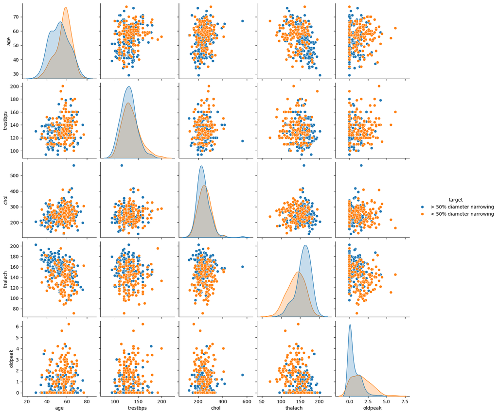

```python
# Visualizing the
cont_data = data_to_use[["age","trestbps","chol","thalach","oldpeak","target"]].copy()
cont_data['target'] = cont_data['target'].replace({0: '< 50% diameter narrowing', 1: '> 50% diameter narrowing'})

sns.pairplot(cont_data ,hue = "target" )
plt.show()
```

### Let's make a heatmap of all the numeric variables

- Heatmap is also used to understand the best set of features to explain a relationship between two variables .
- It is usually not used that much in drawing any final conclusions but a great way to visualize the relation between features by looking at the different color representation of them.
- The heat map shows the relative intensity of values captured by your eye tracker by assigning each value a color representation.

```python
df2 = data_to_use[['age', 'sex','cp','trestbps','chol','fbs','restecg','thalach','exang','oldpeak','slope','ca','thal']].copy()
print(df2)
```

```
     age  sex  cp  trestbps  chol  fbs  restecg  thalach  exang  oldpeak  \
0     63    1   3       145   233    1        0      150      0      2.3
1     37    1   2       130   250    0        1      187      0      3.5
2     41    0   1       130   204    0        0      172      0      1.4
3     56    1   1       120   236    0        1      178      0      0.8
4     57    0   0       120   354    0        1      163      1      0.6
..   ...  ...  ..       ...   ...  ...      ...      ...    ...      ...
298   57    0   0       140   241    0        1      123      1      0.2
299   45    1   3       110   264    0        1      132      0      1.2
300   68    1   0       144   193    1        1      141      0      3.4
301   57    1   0       130   131    0        1      115      1      1.2
302   57    0   1       130   236    0        0      174      0      0.0

     slope  ca  thal
0        0   0     1
1        0   0     2
2        2   0     2
3        2   0     2
4        2   0     2
..     ...  ..   ...
298      1   0     3
299      1   0     3
300      1   2     3
301      1   1     3
302      1   1     2

[303 rows x 13 columns]
```

```python
corr_matrix = df2.corr()
```

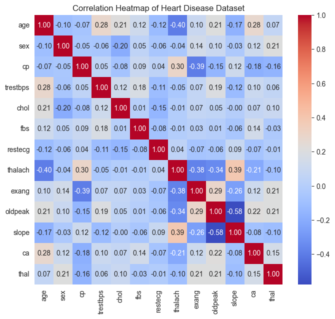

```python
plt.figure(figsize=(8, 7))
sns.heatmap(corr_matrix, annot=True, fmt=".2f", cmap='coolwarm', cbar=True)
plt.title("Correlation Heatmap of Heart Disease Dataset")
plt.show()
```

## Visualising Categorical Variables

As you might have noticed, there are a few categorical variables as well. Let's make a boxplot for some of these variables.

- Outliers(for a normal distribution).
- “Minimum” and “Maximum” of different categories in a boxplot.

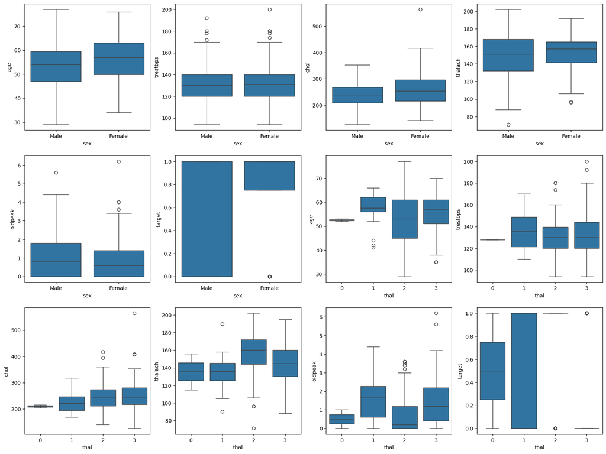

```python
categ_data_to_use_in_boxplot = data_to_use[['sex','thal']].copy()
categ_data_list = categ_data_to_use_in_boxplot.columns.values.tolist()
cont_data_list = cont_data.columns.values.tolist()
data_modified = data.copy()
data_modified['sex'] = data_modified['sex'].replace({0: 'Female', 1: 'Male'})


plt.figure(figsize=(20,15))

a = 1
for i in enumerate(categ_data_list):
    for j in enumerate(cont_data_list):
        plt.subplot(3,4,a)
        sns.boxplot(x=i[1], y= j[1], data=data_modified)
        a +=1

plt.subplots_adjust(hspace = 0.2)

plt.show()
```

#### Observations:

##### By observing boxplots of thal(a blood disorder called thalassemia) against different features we get to know that

- Thal **value of 2**(**normal blood flow**) has lowest minimum and highest maximum which denotes its relationship against age.It has biggest IQR when compared to other thal values quartiles. Most common Thal value for all age groups is thal value 2(normal blood flow).
- Thal **value of 1**(**fixed defect** (no blood flow in some part of the heart)) against age is between **50 and 70 years old.**
- Thal **value of 3**(**reversible defect** (a blood flow is observed but it is not normal)) against age have its median at **58 years** old approximately.
- In **thal vs chol** plot we can see that the medians of cholestrol levels are increasing as thal values are increasing which shows that cholestrol level and thalessemia are positively correlated.
- In **thal vs thallach** plot we can see that **median of thal value 2 is greatest** which denotes that even after having normal blood flow the range of maximum heart reate achieved is greater than other thal values.

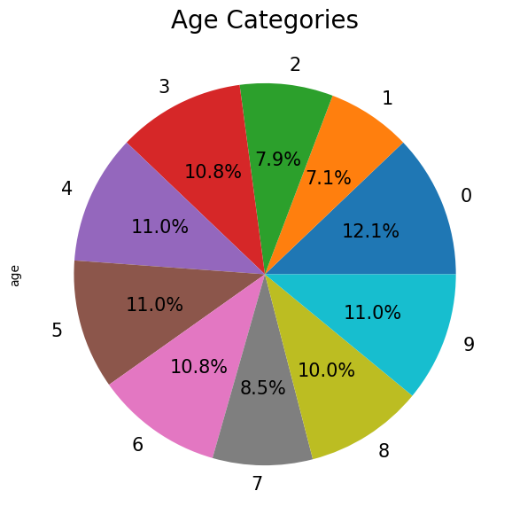

```python
plt.figure(figsize=(7,7))
df = data.age.value_counts().to_frame()
textprops = {"fontsize":15}
df2.head(10).age.plot(kind='pie',autopct='%1.1f%%',textprops =textprops )

plt.title("Age Categories",fontsize = 20)
plt.show()
```

## Let's visualize more about some important relation between features and target variable

### Histogram plot

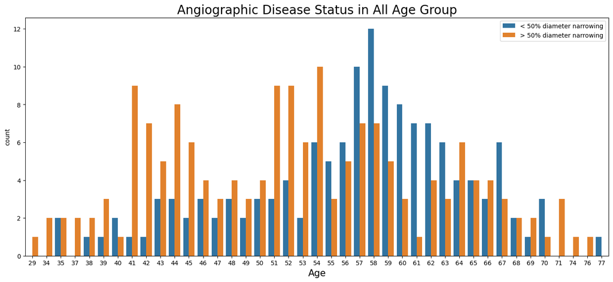

```python
plt.figure(figsize=(17,7))
ax = sns.countplot(x="age", hue="target", data=data_to_use)
plt.title("Angiographic Disease Status in All Age Group",fontsize = 20)
plt.legend(["< 50% diameter narrowing","> 50% diameter narrowing"],loc='upper right')
plt.xlabel("Age",fontsize = 15)
plt.show()
```

#### Observations:

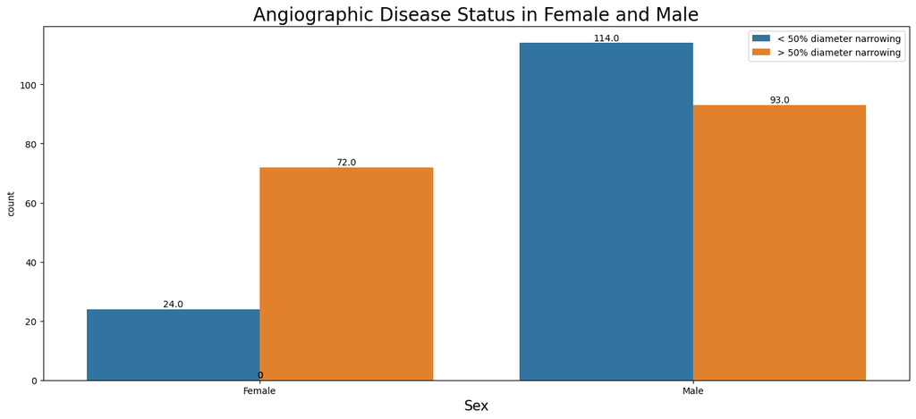

```python
x = ["Female","Male"]
values = range(len(x))

plt.figure(figsize=(17,7))
ax = sns.countplot(x="sex", hue="target", data=data_to_use)
for rect in ax.patches:
    ax.text (rect.get_x() + rect.get_width()  / 2,rect.get_height()+ 0.75,rect.get_height(),horizontalalignment='center', fontsize = 10)
plt.title("Angiographic Disease Status in Female and Male",fontsize = 20)
plt.legend(["< 50% diameter narrowing","> 50% diameter narrowing"],loc='upper right')
plt.xlabel("Sex",fontsize = 15)
plt.xticks(values,x)
plt.show()
```

#### Observations

- *Such difference in male and female plot is due to less records of female present in dataset.*
- Ratio of more susceptible to a possible heart attack to less susceptible in **female** is **3:1**.
- Ratio of more susceptible to a possible heart attack to less susceptible in **male** is almost **3:4**.

### Violin plot used for categorical data

Analyzing relationship between age and sex with target variable in single plot

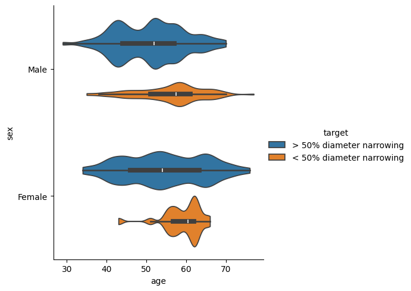

```python
data_modified['target'] = data_modified['target'].replace({0: '< 50% diameter narrowing', 1: '> 50% diameter narrowing'})
plt.figure(figsize=(10,7))
sns.catplot(x="age", y="sex",
            hue="target",
            data=data_modified,
            orient="h", height=5, aspect=1, palette="tab10",
            kind="violin", dodge=True, cut=0, bw=.2)

plt.show()
```

#### Observations:

- In plot of female, where target: > 50% diameter narrowing (more susceptible to a heart attack), the range of age is greater and evenly distributed with flatter peaks.
- Whereas in plot of female, where target: < 50% diameter narrowing (less susceptible to a heart attack), the range of age is shorter and has higher peaks at certain age groups near 55 years and 62 years.
- We can see there are very less outliers in dataset.

### Probablity Density Plot of Some More Features

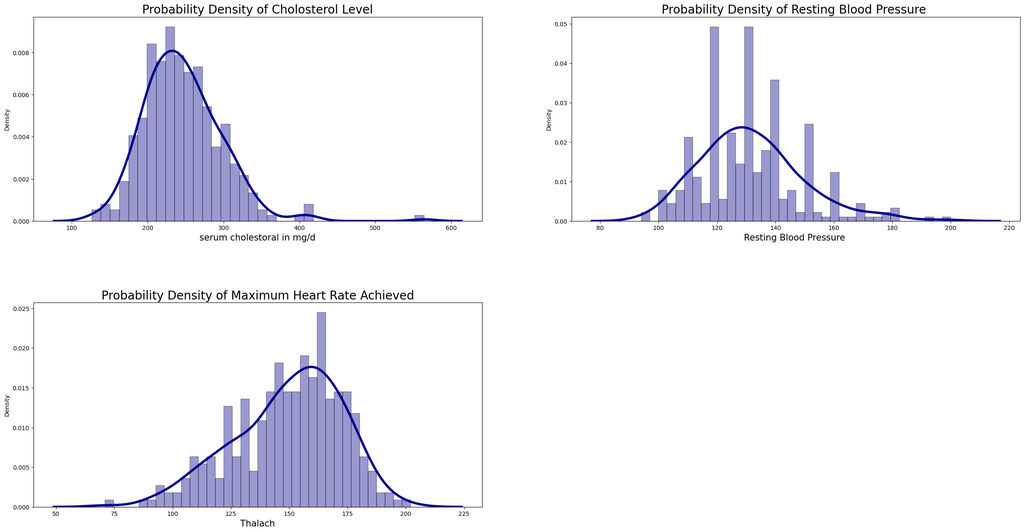

```python
plt.figure(figsize = (30,15))
a = 1
for i in ["chol","trestbps","thalach"]:

    plt.subplot(2,2,a)
    sns.distplot(data_to_use[i],hist=True, kde=True,
                 bins=int(180/5), color = 'darkblue',
                 hist_kws={'edgecolor':'black'},
                 kde_kws={'linewidth': 4})
    if i=="chol":

        plt.title("Probability Density of Cholosterol Level",fontsize = 20)
        plt.xlabel("serum cholestoral in mg/d",fontsize = 15)

    elif i == "thalach":
        plt.title("Probability Density of Maximum Heart Rate Achieved",fontsize = 20)
        plt.xlabel("Thalach",fontsize = 15)

    else:
        plt.title("Probability Density of Resting Blood Pressure ",fontsize = 20)
        plt.xlabel("Resting Blood Pressure ",fontsize = 15)
    a+=1

plt.subplots_adjust(hspace = 0.4)
plt.show()
```

### Line plot of cholosterols level and Thalach in male and female with their ages

- Serum cholesterol levels helps in figuring out risk for developing heart disease.
- The maximum heart rate greater than (220-present age) is considerd hazardous.

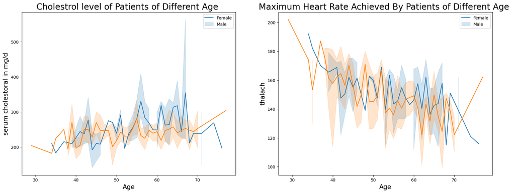

```python
plt.figure(figsize = (20,7))
a = 1
y = ["chol","thalach"]
for feature in y:
    plt.subplot(1,2,a)
    sns.lineplot(data=data_to_use, x="age", y=feature,hue = "sex")
    plt.xlabel("Age",fontsize = 15)
    plt.legend(["Female", "Male"], loc ="upper right")

    if feature=="chol":
        plt.title("Cholestrol level of Patients of Different Age ",fontsize = 20)
        plt.ylabel("serum cholestoral in mg/d",fontsize = 15)
    else:
        plt.title("Maximum Heart Rate Achieved By Patients of Different Age ",fontsize = 20)
        plt.ylabel("thalach",fontsize = 15)
    a+=1
plt.show()
```

#### Observations:

- Serum cholestrol level in Female is higher than Male between the age of 52 years to 68 years.
- From the thalach plot we can see that as the age is increasing the chart is showing downward trend directing towards the fact that maximum heart rate achieved decreases as the person grows older.

#### Data preparation

```python
X = data_to_use.drop("target",axis =1)
y = data_to_use["target"]

datalist = data.columns.values.tolist()
datalist.remove("target")
```

**Model Building - Logistic Regression**

Before applying Logistic Regression ,

- We will split the data into train-test set.
- Then data will be scaled.
- For continuos data Normalization technique (MinMaxscaler) is used.
- for categorical data Mean encoding technique is used.

#### Splitting the dataset into train and test dataset

```python
from sklearn.model_selection import train_test_split
from sklearn.preprocessing import MinMaxScaler

X_train, X_test, y_train, y_test= train_test_split(X,y, test_size= 0.25, random_state=120)
```

#### Scaling of Train Data

```python
# Target Mean Encoding for categorical columns in train data

for i in ['age','cp','restecg','slope','ca','thal'] :
    Mean_encoded_variable = data_to_use.groupby([i])['target'].mean().to_dict()

    X_train[i] =  X_train[i].map(Mean_encoded_variable)

# Normalization for continuos column in train data

scaler = MinMaxScaler()
num_vars = ['trestbps', 'chol', 'thalach', 'oldpeak']

# Fit on object

X_train[num_vars] = scaler.fit_transform(X_train[num_vars])
```

#### Training of the Model using Logistic Regression

```python
from sklearn.linear_model import LogisticRegression

model= LogisticRegression()

model.fit(X_train, y_train)
trainscore =  model.score(X_train,y_train)
```

#### Scaling of Test Data and Applying Test Data on Model

```python
# Target Mean Encoding on categorical columns in test data
for i in ['age','cp','restecg','slope','ca','thal'] :
    Mean_encoded_variable1 = data_to_use.groupby([i])['target'].mean().to_dict()

    X_test[i] =  X_test[i].map(Mean_encoded_variable1)

# Normalization for continuos columns in test data

X_test[num_vars] = scaler.transform(X_test[num_vars])

testscore =  model.score(X_test,y_test)
```

#### Test Score and Train Score

```python
print("test score: {} \ntrain score: {}".format(testscore*100,trainscore*100),'\n')

y_pred =  model.predict(X_test)
```

```
test score: 88.1578947368421
train score: 84.14096916299559
```

#### Confusion Matrix

```python
from sklearn.metrics import confusion_matrix

print("Confusion Matrix : \n",confusion_matrix(y_test, y_pred))
```

```
Confusion Matrix :
 [[29  4]
 [ 5 38]]
```

#### Different Classification Metrics

```python
from sklearn.metrics import classification_report,accuracy_score,f1_score,precision_score,recall_score,roc_curve,roc_auc_score

print(' f1 score: ',f1_score(y_test, y_pred)*100,'\n')
print(' Accuracy: ',accuracy_score(y_test, y_pred)*100,'\n')
print(' precision score: ',precision_score(y_test, y_pred)*100,'\n')
print(' recall score: ',recall_score(y_test, y_pred)*100,'\n')
print("Classification report: \n",classification_report(y_test, y_pred))
```

```
 f1 score:  89.41176470588236

 Accuracy:  88.1578947368421

 precision score:  90.47619047619048

 recall score:  88.37209302325581

Classification report:
               precision    recall  f1-score   support

           0       0.85      0.88      0.87        33
           1       0.90      0.88      0.89        43

    accuracy                           0.88        76
   macro avg       0.88      0.88      0.88        76
weighted avg       0.88      0.88      0.88        76
```

```python
probabilityValues = model.predict_proba(X_test)[:,1]
auc = roc_auc_score(y_test, y_pred)
print("AUC Score: ",auc*100)
```

```
AUC Score:  88.12544045102186
```